# Validasi Rugi-Rugi dan Resistansi Internal Kabel: TB 880 Case 8, Case 2, dan TB 908 Method 1

Progress Update — Langkah 5a dan 5b-i · Risk-Constrained Probabilistic Thermal Rating, J-Tube Kabel Ekspor Offshore Wind

Joko Pawitro — NRP 6022251005

Program Magister, Rekayasa Elektrik Berkelanjutan — Departemen Teknik Elektro, ITS

2026-09-21

## Agenda

1. Progress update (berdasarkan `PROGRESS.md`)
2. TB 880 Case 8 — validasi jalur non-magnetik (5a)
3. TB 880 Case 2 — validasi jalur magnetik (5a), dan mengapa ditambahkan
4. TB 908 Method 1 — 5b-i selesai, 5b-ii ditunda
5. Dokumen rujukan

## 1. Progress — ringkasan langkah

| # | Langkah | Status | Catatan |
| --- | --- | --- | --- |
| 1 | Persiapan data ERA5 + parameter | ✅ Selesai | 87.672 jam, tanpa *gap* |
| 2 | Tahun representatif | ✅ Selesai | Tinggi 2017 · Median 2018 · Rendah 2021 |
| 3 | Konversi *wind-to-current* | ✅ Selesai | 12 *regression test* |
| **5** | **Model termal J-tube kuasi-stasioner** | **🟡 Parsial** | **5a ✅ · 5b-i ✅ · 5b-ii, 5c–5f belum** |
| 4 | Skenario *block-bootstrap* Monte Carlo | ❌ Belum | Dapat dibangun sekarang; diturunkan prioritasnya (Langkah 5 = jalur kritis) |
| 6–9 | `I_α`, umur XLPE, baseline + sensitivitas, pelaporan | ❌ Belum | Bergantung pada Langkah 5 |

Langkah 5 tetap **risiko jadwal tertinggi**: slot Sep–Okt dua bulan tanpa *buffer* (keputusan 13 September: diterima tanpa buffer). Sub-langkah 5a dan 5b-i selesai dalam pekan ini; **5c (jaringan eksternal J-tube) adalah langkah berikutnya**.

## 1. Progress — status Langkah 5 dan perubahan dari rencana

```
flowchart LR
    S5a["<b>5a</b> Rugi-rugi + T1–T3<br/>Case 8 ✅ · Case 2 ✅"]:::done
    S5bi["<b>5b-i</b> TB 908 Method 1<br/>standalone ✅"]:::done
    S5c["<b>5c</b> Jaringan eksternal J-tube<br/>⏭ berikutnya"]:::next
    DEC{{"Keputusan armour base-case<br/>magnetik vs non-magnetik<br/>(ditunda ke 5c)"}}:::open
    S5bii["<b>5b-ii</b> Switch LOSS_STANDARD<br/>⏸ ditunda"]:::deferred
    S5d["<b>5d</b> Uji arah fisika"]:::todo
    S5e["<b>5e</b> Konstanta waktu τ"]:::todo
    S5f["<b>5f</b> Precompute I_max(t)"]:::todo
    S5a --> S5bi
    S5a --> S5c
    S5c --> DEC --> S5bii
    S5c --> S5d --> S5e --> S5f
    classDef done fill:#c6f6d5,stroke:#2f855a,color:#1a202c
    classDef next fill:#bee3f8,stroke:#2b6cb0,color:#1a202c
    classDef open fill:#fefcbf,stroke:#b7791f,color:#1a202c
    classDef deferred fill:#fed7aa,stroke:#c05621,color:#1a202c
    classDef todo fill:#edf2f7,stroke:#718096,color:#1a202c
```

**Berbeda dari rencana 14 September:**

- **5a: Case 8 + Case 2.** Rencana hanya Case 8; armour Case 8 non-magnetik (λ₂ = 0), jadi jalur λ₂ tak pernah dieksekusi → Case 2 ditambahkan.
- **5b dipecah:** 5b-i (modul Method 1, tervalidasi, selesai) dan 5b-ii (wiring `LOSS_STANDARD`, ditunda) — Method 1 mengembalikan `R_AC, λ₁, λ₂` sekaligus dan wiring butuh keputusan armour *base-case*.
- **Uplift TB 908:** bukan “~10 %”, melainkan +6 / +11 / +14 % menurut μ<sub>r</sub> dan arah *lay* (contoh 245 kV 3×1200 mm² Al; TB 908 (2023), Tabel 7.9).
- **Dua errata sumber:** GP 33 (TB 880) dan y<sub>p</sub> (TB 908 Lamp. C), ditemukan saat mereproduksi *reference value*.

## 1. Progress — hasil pekan ini dan item terbuka

| Target validasi | Benchmark | Hasil |
| --- | --- | --- |
| **5a — non-magnetik** | TB 880 Case 8 (220 kV, 3×1000 mm²) | 18/18 nilai antara cocok (`rel ≤ 1e-9`); `I` = 1134.8197 A (terbit 1134.8197 A) → GP 2: 1130 A |
| **5a — magnetik** | TB 880 Case 2 (30 kV, 3×630 mm², baja galvanis) | 59/59 nilai terbit cocok; `I` = 838.3400 A → 830 A |
| **5b-i — TB 908 Method 1** | TB 908 Lampiran E, C, Tabel 3.1 | 17/17 kasus Lamp. E cocok; Tabel C4 cocok (3 referensi); Tabel 3.1 dalam +0.08…+0.60 % |

Ini memvalidasi **lapisan internal kabel** terhadap benchmark literatur — bukan model J-tube. 226 tes lulus. Dari total kenaikan suhu konduktor terhadap ambien (ΔΘ = θ<sub>c</sub> − θ<sub>amb</sub>), lapisan tanah (`T4`) menyumbang 65 % pada Case 8 dan 68 % pada Case 2 — lapisan inilah yang diganti oleh 5c.

**Item terbuka:**

- **Armour *base-case*** (magnetik vs non-magnetik): ditunda ke 5c; kedua jalur sudah tervalidasi.
- **Input Method 1 kasus tesis** (μ<sub>r</sub>, *lay*, p<sub>c</sub>, p<sub>a</sub>): belum; prasyarat 5b-ii.
- **Prasyarat 5c:** parameter Chippendale (2017) / Høyer-Hansen (2022) belum diekstrak; `A_avail`, `N_CIRCUITS`, geometri J-tube belum ada (tidak memblokir 5c).
- **⚠️ *Capacity factor*** 0.626 vs 0.40–0.55: ditandai, belum dicek terhadap IEA-15MW terpublikasi.

## 2. Case 8 — cakupan dan flowchart

| Item | TB 880 Case Study 8 |
| --- | --- |
| Kabel | FXBLTV 3x1000 mm2, 220 kV, XLPE / timbal / SL, 3 core |
| Armour | baja tahan karat (**non-magnetik**) → λ₂ = 0 (GP 26/36) |
| Pemasangan | terkubur di dasar laut, kedalaman 1 m (Tabel 12-15); ρ tanah 0.7 K·m/W; suhu dasar laut 15 °C |
| Batas termal | θ<sub>c</sub> = 90 °C → ΔΘ = 75 K |

- **Divalidasi:** rantai IEC 60287-1-1 / -2-1 pada lapisan internal, dicocokkan pada **setiap** *published intermediary values*, bukan hanya *ampacity* akhir.
- **Tidak divalidasi:** apa pun yang khusus J-tube. `T4` di sini adalah **tanah** — Case 8 bukan benchmark J-tube.

```
%%{init: {"flowchart": {"nodeSpacing": 18, "rankSpacing": 24, "padding": 12, "diagramPadding": 4}}}%%
flowchart LR
    IN["<b>Masukan</b><br/>Tabel 12-1…12-17"]
    LOSS["<b>Rugi-rugi</b><br/>f_layup → R′<br/>y_s, y_p → R<br/>W_d · R_so · X"]
    THERM["<b>Resistansi termal</b><br/>T1 · T2 (SL)<br/>T3 · T4 terkubur"]
    L1["λ1 = λ1′ + F·λ1″<br/>pada θ_sc"]
    R1["I (IEC 4.2.1)<br/><i>steady_state_rating</i>"]
    U1["θ_sc baru<br/>= θ_c − (I²R<br/>+ ½W_d)·T1"]
    D{"Δθ_sc, ΔI<br/>≤ 1e-10 ?"}
    OUT["<b>I = 1134.82 A</b><br/>GP 2 → 1130 A"]
    IN --> LOSS --> THERM --> L1 --> R1 --> U1 --> D
    D -. "Tidak" .-> L1
    D -- "Ya" --> OUT
```

Fungsi murni per klausul; `rating_with_sheath_iteration` menjalankan *loop* ke konvergen (GP 5: `|Δθ_sc| ≤ 1e-10 K`, `|ΔI| ≤ 1e-10 A`). Non-konvergen → `RuntimeError`, tidak pernah *silent*.

## 2. Case 8 — cuplikan kode

```
def steady_state_rating(
    delta_theta: float,
    r_c: float,
    w_d: float,
    t1: float,
    t2: float,
    t3: float,
    t4: float,
    n: int,
    lambda1: float,
    lambda2: float,
) -> float:
    numerator = delta_theta - w_d * (0.5 * t1 + n * (t2 + t3 + t4))
    denominator = (
        r_c * t1
        + n * r_c * (1.0 + lambda1) * t2
        + n * r_c * (1.0 + lambda1 + lambda2) * (t3 + t4)
    )
    return math.sqrt(numerator / denominator)


def screen_temperature(theta_c: float, i_a: float, r_c: float, w_d: float, t1: float) -> float:
    return theta_c - (i_a**2 * r_c + 0.5 * w_d) * t1
```

```
for iteration in range(1, max_iter + 1):
    r_s = sheath_resistance(r_so, alpha_s, theta_sc)
    lambda1_prime = sheath_circulating_loss_factor(r_s, r_c, x, k=circulating_k)
    rho_s = sheath_resistance(rho_s_20_ohm_m, alpha_s, theta_sc)
    if include_eddy:
        lambda1_pp, m, lambda0, delta1, beta1, g_s = sheath_eddy_loss_factor_trefoil(
            r_s,
            r_c,
            f_hz,
            d_mean_mm,
            s_mm,
            d_s_mm,
            t_s_mm,
            rho_s,
            lead_simplified=lead_simplified,
        )
    else:
        lambda1_pp, m, lambda0, delta1, beta1, g_s = 0.0, None, None, None, None, None
    f_factor = eddy_reduction_factor_trefoil(r_s, x) if apply_f_factor else 1.0
    lambda1 = lambda1_prime + f_factor * lambda1_pp

    # ... cabang armour magnetik: lihat Case 2 ...

    i_a = steady_state_rating(
        delta_theta, r_c, w_d, t1, t2, t3, t4, n, lambda1, lambda2_used
    )
    theta_sc_next = screen_temperature(theta_c, i_a, r_c, w_d, t1)
```

`steady_state_rating` dan `screen_temperature` adalah persamaan rating (IEC 4.2.1) dan pembaruan `θ_sc`; *loop* dikutip langsung dari `rating_with_sheath_iteration` (cabang magnetik dilewati di sini).

## 2. Case 8 — hasil validasi

| Kuantitas | Published (TB 880) | Hasil `src/` | Δ relatif | Terpenuhi |
| --- | --- | --- | --- | --- |
| R′ pada 90 °C, Ω/m | 2.244176e-05 | 2.244176e-05 | 1.5e-16 | ✅ |
| y_s | 0.1444369104 | 0.14443691043 | 1.8e-10 | ✅ |
| y_p | 0.05683893091 | 0.056838930907 | 5.1e-11 | ✅ |
| R per m kabel, Ω/m | 2.7277156257e-05 | 2.7277156257e-05 | 7.2e-12 | ✅ |
| W_d, W/m | 0.9629518229 | 0.96295182288 | 2.1e-11 | ✅ |
| T1, K·m/W | 0.48728714947 | 0.48728714947 | 8.3e-12 | ✅ |
| T2, K·m/W | 0.02641373992 | 0.026413739921 | 2.5e-11 | ✅ |
| T3, K·m/W | 0.03170182109 | 0.031701821086 | 1.3e-10 | ✅ |
| T4 terkubur, K·m/W | 0.3107202651 | 0.31072026514 | 1.3e-10 | ✅ |
| θ_sc konvergen, °C | 72.647984791 | 72.647984791 | 5.9e-16 | ✅ |
| λ₁ konvergen | 0.4557096608 | 0.45570966083 | 6.1e-11 | ✅ |
| **I akhir, A** | 1134.8196615 | 1134.8196615 | 2.8e-14 | ✅ |

Terpenuhi bila `rel ≤ 1e-9` (*published value* ±10–11 digit signifikan, GP 1); toleransi tidak pernah dilonggarkan. Peringkat GP 2: 1130 A. Konvergen dalam 8 iterasi. **Koreksi audit:** `k = 1` pada `λ₁′` dipilih oleh **GP 38**, bukan GP 36 (GP 36 hanya membenarkan `λ₂ = 0`).

**Rujukan:** CIGRE TB 880 (2022), Case Study 8 (Tabel 12-1…12-18; GP 1, 2, 4, 5, 6, 8, 20, 23, 26, 31, 36, 38, 44, 45); IEC 60287-1-1:2023 §4.2.1, §5.1–5.3; IEC 60287-2-1:2023 §4.1.3–4.1.5.1, §4.2.2.

## 3. Case 2 — mengapa ditambahkan (berbeda dari rencana)

|  | Rencana (deck 14 Sep) | Yang terjadi |
| --- | --- | --- |
| **Validasi 5a** | TB 880 Case 8 | Case 8 selesai → audit → **Case 2 ditambahkan** |
| **Temuan** | — | Armour Case 8 non-magnetik → **λ₂ = 0** → jalur armour magnetik **tidak pernah dieksekusi** |

**Jalur yang tidak pernah disentuh Case 8:** faktor GP 25 (1.5 pada `y_s + y_p`), `k = 1.5` (GP 38), `λ₂` (IEC 5.4.3.3.1) dengan reduksi SL (GP 37), suhu armour `θ_ar` + iterasi dua-temperatur, dan `R₀` per kabel jadi (IEC 60228, tanpa `f_layup`).

|  | Case 8 | Case 2 |
| --- | --- | --- |
| Kabel | 220 kV, 3×1000 mm² SL | 30 kV, 3×630 mm² SL |
| Armour | baja tahan karat — non-magnetik | baja galvanis — **magnetik** |
| λ₂ | 0 (GP 36) | IEC 5.4.3.3.1 × reduksi SL (GP 37) |
| R₀ | per inti, × f_layup | per kabel jadi, tanpa f_layup |
| Iterasi hingga konvergen | 8 (θ_sc) | 7 (θ_sc dan θ_ar) |
| I (A) | 1134.8197 | 838.3400 |

- **Cakupan dan base-case:** 5a mencakup `λ₂` (menyatakannya selesai tanpa jalur magnetik = *over-claim*); armour baja galvanis adalah kandidat *base-case* (keputusan ditunda ke 5c), jadi **kedua** jalur harus tervalidasi lebih dulu.
- **Batasan:** Case 2 adalah kabel *array* 30 kV, bukan kabel ekspor — ia memvalidasi **jalur rugi-rugi**, bukan kabel tesis.

## 3. Case 2 — flowchart dan persamaan

```
%%{init: {"flowchart": {"nodeSpacing": 18, "rankSpacing": 24, "padding": 12, "diagramPadding": 4}}}%%
flowchart LR
    PRE["<b>Pra-iterasi</b><br/>GP 25: R = R′[1 +<br/>1.5(y_s + y_p)]<br/>R_A0 (GP 32, 34)<br/>c (GP 33 metode 2)"]
    A1["R_s(θ_sc) → λ1′<br/>(k = 1.5, GP 38)<br/>λ1″, F (GP 6, 31)<br/>→ λ1"]
    A2["R_A(θ_ar)<br/>λ2 mentah<br/>(IEC 5.4.3.3.1)"]
    A3["× reduksi SL<br/>(GP 37)<br/>1 − (R/R_s)·λ1′"]
    A4["I = steady_<br/>state_rating<br/>(λ1, λ2)"]
    A5["θ_sc, θ_ar<br/>baru dari I"]
    D{"Δθ_sc, Δθ_ar,<br/>ΔI ≤ 1e-10 ?"}
    OUT["<b>I = 838.34 A</b><br/>7 iterasi<br/>GP 2 → 830 A"]
    PRE --> A1 --> A2 --> A3 --> A4 --> A5 --> D
    D -. "Tidak" .-> A1
    D -- "Ya" --> OUT
```

$$\begin{aligned}
R &= R'\left[1+1.5\,(y_s+y_p)\right]\ \ (\text{GP 25})\\
\theta_{ar} &= \theta_c-\Big\{(I^2R+0.5W_d)T_1+\big[I^2R(1+\lambda_1)+W_d\big]\,n\,T_2\Big\}
\end{aligned}$$

$$\begin{aligned}
\lambda_2^{\text{mentah}} &= 1.23\,\frac{R_A}{R}\,\frac{(2c/d_A)^2}{\left(2.77\,R_A\,10^6/\omega\right)^2+1}\\
\lambda_2 &= \lambda_2^{\text{mentah}}\cdot\max\!\left(0,\,1-\frac{R}{R_s}\lambda_1'\right)
\end{aligned}$$

Mode `armour="magnetic"` pada fungsi iterasi **yang sama** dengan Case 8; argumen yang tidak berlaku menyebabkan `ValueError`. IEC 60287-1-1:2023 §5.4.1, §5.4.3.3.1, §5.4.3.5, §5.3.11; TB 880 GP 25, 26, 32–34, 37, 38.

## 3. Case 2 — cuplikan kode

```
def armour_loss_factor_3core_round_wire(
    r_a: float, r_c: float, c_mm: float, d_a_mm: float, f_hz: float
) -> float:
    omega = 2.0 * math.pi * f_hz
    return (
        1.23 * (r_a / r_c) * (2.0 * c_mm / d_a_mm) ** 2 / ((2.77 * r_a * 1e6 / omega) ** 2 + 1.0)
    )


def sl_armour_reduction_factor(r_c: float, r_s: float, lambda1_prime: float) -> float:
    return max(0.0, 1.0 - (r_c / r_s) * lambda1_prime)
```

```
for iteration in range(1, max_iter + 1):
    # ... R_s, λ1′, λ1″, F, λ1 seperti Case 8 ...

    if magnetic:
        r_a = armour_resistance(r_ao, alpha_a, theta_ar)
        reduction = sl_armour_reduction_factor(
            r_c, r_s, sheath_circulating_loss_factor(r_s, r_c, x, k=reduction_k)
        )
        lambda2_used = (
            armour_loss_factor_3core_round_wire(r_a, r_c, c_mm, d_a_mm, f_hz) * reduction
        )
    else:
        r_a = None
        reduction = None

    # ... i_a = steady_state_rating(..., lambda1, lambda2_used) ...
```

Docstring `λ₂` membawa catatan IEC sendiri: rumus ini “*can overestimate*” — alasan dibutuhkan TB 908.

## 3. Case 2 — hasil validasi

| Kuantitas | Published (TB 880) | Hasil `src/` | Δ relatif | Terpenuhi |
| --- | --- | --- | --- | --- |
| R per m, Ω/m (dengan GP 25) | 4.2109811659e-5 | 4.2109811659e-05 | 4.7e-12 | ✅ |
| R_A0 (20 °C), Ω/m | 1.0398021064e-4 | 0.00010398021064 | 4.3e-11 | ✅ |
| c, mm (GP 33 metode 2) | 36.4 | 36.4 | 2.0e-16 | ✅ |
| T1, K·m/W | 0.3578707848 | 0.35787078481 | 2.0e-11 | ✅ |
| T2, K·m/W | 0.0779300464 | 0.077930046415 | 1.9e-10 | ✅ |
| T3, K·m/W | 0.0376252079 | 0.037625207932 | 8.5e-10 | ✅ |
| T4 terkubur, K·m/W | 0.3617633359 | 0.36176333588 | 4.7e-11 | ✅ |
| θ_sc konvergen, °C | 79.3851216214 | 79.385121621 | 3.2e-13 | ✅ |
| θ_ar konvergen, °C | 71.308546665890 | 71.308546666 | 3.5e-14 | ✅ |
| λ₁ | 0.1628367815 | 0.16283678149 | 6.2e-11 | ✅ |
| λ₂ (setelah reduksi SL) | 0.4206526837 | 0.42065268367 | 8.1e-11 | ✅ |
| **I akhir, A** | 838.3399739336 | 838.33997393 | 8.0e-14 | ✅ |

**59/59 *published value* terpenuhi.** Terpenuhi bila `rel ≤ 1e-9` **atau** ≤ 1 satuan digit terakhir yang dicetak — *published value* Case 2 punya jumlah digit tidak seragam (mis. λ₀ hanya 8 digit).

**Rujukan:** CIGRE TB 880 (2022), Case Study 2 (Tabel 6-1…6-19; GP 6, 23, 25, 26, 31–34, 37, 38, 44, 45); IEC 60287-1-1:2023 §5.4.1, §5.4.3.1, §5.4.3.3.1, §5.4.3.5, §5.3.11; IEC 60228 (`R₀` per kabel jadi).

## 3. Case 2 — λ₂ terhadap R_A dan register M1–M5

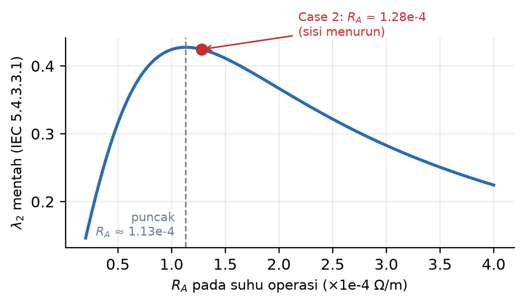

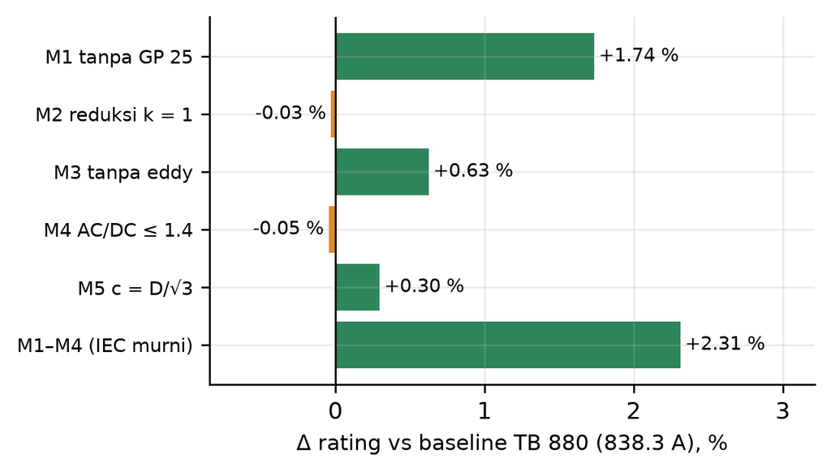

Anggapan awal “`λ₂` naik dengan `R_A`” **keliru**: `λ₂ ∝ R_A/[(2.77R_A·10⁶/ω)² + 1]` punya puncak, dan `R_A` Case 2 ada di **sisi menurun** — armour lebih panas memberi rating **lebih tinggi**; perbandingan TB 908 vs IEC tidak boleh mengasumsikan monotonisitas. M1–M5 adalah pilihan panduan TB 880 (bukan kesalahan) dan dapat dipilih lewat kata kunci; **tidak ada yang menjadi parameter sensitivitas tesis**.

## 3. Case 2 — erratum GP 33 metode 1

| Bentuk `c` | c (mm) | I (A) | Δ vs published |
| --- | --- | --- | --- |
| Metode 2: (D_assembly − D_core)/2 — **default `src/`** | 36.400 | 838.34 | — |
| Geometris D_core/√3 (`method="trefoil"`) | 35.853 | 840.83 | +0.30 % |
| Metode 1 **seperti tercetak**: (√3/2)·D_core — *tidak* diimplementasikan | 53.780 | 754.47 | -10.00 % |

- (√3/2)·D adalah **tinggi** segitiga sama sisi; pusat kabel berjarak D/√3 dari sumbu inti, jadi bentuk tercetak 50 % terlalu besar. Tepi luar inti berada di 84.8 mm dari pusat — **melewati** jari-jari dalam armour 68.65 mm: secara fisik mustahil.
- Tidak konsisten dengan metode 2 di GP 33 sendiri; dampak -10.0 % *ampacity*. Diverifikasi terhadap halaman TB 880 asli; **tidak** diimplementasikan.

## 4. TB 908 — 5b-i selesai, 5b-ii ditunda

| ✅ 5b-i — selesai | ⏸ 5b-ii — ditunda |
| --- | --- |
| Modul murni `thermal/tb908.py`: `R_AC`, `λ₁`, `λ₂` **bersamaan** + setiap intermediat Tabel C4 | *Flag* `LOSS_STANDARD` (`iec60287` atau `tb908`) di `config.py` |
| Divalidasi terhadap angka TB 908 sendiri: Lampiran E, Lampiran C, Tabel 3.1 | Sambungan ke iterasi rating di `ampacity.py` |
| 83 tes baru (226 tes terpenuhi); dependensi runtime baru: `scipy` | Iterasi suhu dengan rugi Method 1 (TB 908 §7.2.3) |
| `ampacity.py` **tidak disentuh** | Ganti-nama *hook* `armour_loss_method` (nilai `"tb908"` masih `NotImplementedError`); tes regresi dua cabang |

**Mengapa 5b-ii ditunda:** wiring butuh (1) keputusan armour *base-case* (ditunda ke 5c) dan (2) input kasus tesis yang tidak ada di Case 2/Case 8 — μ<sub>r</sub>, arah *lay*, p<sub>c</sub>, p<sub>a</sub>. TB 908 dilaporkan sebagai sensitivitas Langkah 8 dan IEC 60287 tetap *baseline*, sehingga 5b-ii berada di luar jalur kritis.

- Catatan IEC 60287 sendiri: rumus `λ₂` “*can overestimate*” rugi armour kabel 3-cores.
- TB 908 Method 1 adalah **model impedansi analitis baru** (permeabilitas armour kompleks-anisotropik, deret Bessel, kopling konduktor–screen–armour), bukan revisi rumus IEC. Method 2 (rangkaian ekuivalen) hanya dirujuk, tidak direproduksi.

## 4. TB 908 — flowchart dan persamaan

```
%%{init: {"flowchart": {"nodeSpacing": 18, "rankSpacing": 24, "padding": 12, "diagramPadding": 4}}}%%
flowchart LR
    IN["<b>Masukan</b><br/>geometri, R_DC,<br/>ρ_s, ρ_A, μ_r,<br/>lay, p_c, p_a, I_c"]
    G["<b>Geometri, lay</b><br/>l_c, l_A, θ_a<br/>t, d_a, K_c"]
    C["<b>Konduktor</b><br/>σ_c, κ_c →<br/>Z_skin, Z_prox"]
    A["<b>Armour</b><br/>μ_par, μ_perp<br/>(Pers. 3.6) → μ_eff<br/>Z_A = Σ Z_A,m"]
    S["<b>Screen</b><br/>Z_prox,sc<br/>X_s · X_c"]
    K["<b>Kopling</b><br/>faktor amplifikasi<br/>Z_A^prox · I_s"]
    O["<b>Keluaran bersama</b><br/>y_s, y_p → R_AC<br/>λ1, λ2<br/>P_cond, P_s, P_A"]
    W["<b>5b-ii — ditunda</b><br/>ganti (R_AC, λ1, λ2)<br/>sekaligus"]
    IN --> G --> C --> A --> S --> K --> O -.-> W
```

$$Z_{A,m}=\tfrac{1}{12}\,j\omega\,l_A N\pi d_f^2\mu_0\,\mu_\text{eff}\;\frac{\left[T_m K_m(\eta r_A)\right]^2}{1+\eta\,t\,\mu_\text{eff}/\tau_m},\quad \eta=\frac{2\pi|m|}{p_c},\quad Z_A=\sum_m Z_{A,m}$$

$$\begin{aligned}
R_{AC} &= R_{DC}\Big[1+y_s+y_p\big(1+8\pi\,\mathrm{Re}\{Z_{A1}/(j\omega\mu_0)\}\big)\Big]\\
\lambda_1 &= \frac{R_s|I_s/I_c|^2+\mathrm{Re}\{Z^A_\text{prox,sc}\}\,|1+I_s/I_c|^2}{R_{AC}},\qquad
\lambda_2=\frac{\mathrm{Re}\{Z_A^\text{prox}\}\,|1+I_s/I_c|^2}{R_{AC}}
\end{aligned}$$

TB 908 (2023) §3.2 (ringkasan §3.2.9), Pers. 3.1, 3.6, 3.7, 3.10. `λ₁` dan `λ₂` dinormalisasi terhadap `R_AC` milik Method 1 sendiri, sehingga mengganti `λ₂` saja pada IEC akan **menghitung ganda** efek yang sudah ditangani GP 25 / 37 / 38 → **keputusan D2: ganti `R_AC`, `λ₁`, `λ₂` sekaligus.**

## 4. TB 908 — cuplikan kode

```
amplification = armour_proximity_amplification(z_a1, f_hz)
z_a_prox_ = z_a_prox(armour, z_prox_, z_prox_sc_, f_hz)
z_prox_a = z_prox_ * amplification
z_prox_sc_a = z_prox_sc_ * amplification

i_s = screen_circulating_current(
    i_c_a, r_s, x_s, z_a_prox_ + z_prox_sc_a + z_prox_a, bonded=bonded
)
is_over_ic = i_s / i_c_a
z_cable_ = z_cable(z_skin_, x_c, x_s, z_a_prox_, z_prox_a, z_prox_sc_a, is_over_ic)

y_s_ = y_s(z_skin_, r_dc_ohm_per_m)
y_p_ = y_p(z_prox_, r_dc_ohm_per_m, is_over_ic)
r_ac_ = r_ac(r_dc_ohm_per_m, y_s_, y_p_, amplification)
lambda1_ = lambda1(r_s, is_over_ic, z_prox_sc_a, r_ac_)
lambda2_ = lambda2(z_a_prox_, is_over_ic, r_ac_)
```

```
def y_p(z_prox_: complex, r_dc_ohm_per_m: float, is_over_ic: complex) -> float:
    return z_prox_.real / r_dc_ohm_per_m * screen_current_factor(is_over_ic)


def lambda2(z_a_prox_: complex, is_over_ic: complex, r_ac_ohm_per_m: float) -> float:
    return z_a_prox_.real * screen_current_factor(is_over_ic) / r_ac_ohm_per_m
```

Implementasi dikutip langsung dari `method1_losses`. Faktor `|1 + I_s/I_c|²` adalah **bagian dari rumus** `y_p` — titik yang membedakan modul ini dari `y_p` tercetak di Tabel C4.

## 4. TB 908 — validasi (1/2): Lampiran E

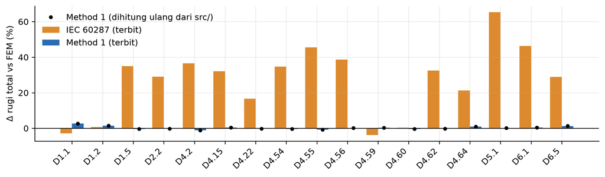

**17/17 kasus Lampiran E terverifikasi.** Deviasi terburuk, dalam satuan digit terakhir yang dicetak: konduktor 1.57 · sheath 0.71 · armour 0.79 · total 1.72 (kolom konduktor dan total mengizinkan pembulatan `R_DC` 4 digit, diturunkan dari masukan, bukan disetel ke hasil). Method 1 terhadap FEM: |Δ| ≤ 2.6 %. IEC terhadap FEM: +17…+65 % pada armour magnetik (μ<sub>r</sub> ≠ 1), tetapi hanya -3.8…+0.7 % pada kasus non-magnetik / tanpa armour. Kolom FEM dan IEC adalah angka rujukan, bukan target reproduksi.

## 4. TB 908 — validasi (2/2): Lampiran C, Tabel 3.1, batasan

| Baris C4 | Published | Kalkulasi | Terpenuhi | Catatan |
| --- | --- | --- | --- | --- |
| mu_eff | 585.7-j258.8 | 585.67-258.81j | ✓ |  |
| z_a_m20 | 2.50E-6+j8.63E-6 Ω/m | 2.498e-06+8.6271e-06j | ✓ |  |
| i_s | -51.33-j164.6 A | -51.425-164.8j | ✓ | ⚠️ 0.13 %, tak material |
| r_ac | 0.0270 Ω/km | 0.027 | ✓ |  |
| lambda1 | 0.441 | 0.44155 | ✓ |  |
| lambda2 | 0.0794 | 0.079377 | ✓ |  |
| p_cond | 81.0 W/m | 81 | ✓ |  |
| p_s | 35.7 W/m | 35.765 | ✓ | ⚠️ pembulatan cetakan |
| p_a | 6.43 W/m | 6.4295 | ✓ |  |

- **Erratum y<sub>p</sub>:** Tabel C4 mencetak y<sub>p</sub> = 0.0567 (tanpa *screen effect factor* 0.927); **rumus** memberi 0.0525 dan `R_AC` = 0.02700 Ω/km, sedangkan y<sub>p</sub> tercetak memberi 0.02713 (`R_AC` tercetak: 0.0270). Modul mengikuti rumus.
- **Tabel 3.1** (rugi armour saja, I = 1000 A): 6 baris dalam +0.08…+0.60 % dari nilai analitis terbit (cek longgar `rel 1e-2`); FEM dilaporkan, tidak di-*assert*; N, ρ<sub>A</sub>, dan *lay* kontralay diinferensikan.
- **Cakupan:** dari 112 kasus D Lampiran E, 100 dapat dievaluasi dan **90 mereproduksi** kolom Method 1 tanpa *tuning* (*scratch sweep*, tidak di-*commit*). 10 yang tidak: inkonsistensi cetakan (D4.61/63), selisih tak terjelaskan 0.3–3 % (D5.10–13), marginal / tanpa armour (D1.3, 1.4, 1.6, D3.5).

**Rujukan:** CIGRE TB 908 (2023) §3.2, Pers. 3.1/3.6/3.7/3.10, Tabel 3.1, Lamp. C dan E, Tabel 7.9, §7.2.3; IEC 60287-1-1:2023 §5.4.3.3.1.

## 5. Dokumen rujukan

| Dokumen | Dipakai untuk | Status |
| --- | --- | --- |
| CIGRE TB 880 (2022), *Current Rating Verification* | Case Study 8 dan 2; Guidance Points (GP 2, 5, 6, 8, 20, 23, 25, 26, 31–38, 44, 45) | Terverifikasi; **bukan** benchmark J-tube |
| CIGRE TB 908 (2023), WG B1.64, *Losses in Armoured Three Core Power Cables* | Method 1 (§3.2), Lampiran C, Lampiran E, Tabel 3.1 / 3.2 | Terverifikasi (e-cigre.org, 13 Sep 2026) |
| IEC 60287-1-1:2023 (Ed. 3.0) | Persamaan rating, rugi-rugi (§5.1–5.4) | Terverifikasi |
| IEC 60287-2-1:2023 (Ed. 3.0) | Resistansi termal `T1–T4` | Terverifikasi |
| IEC 60228 | Konvensi `R₀` per kabel jadi (via TB 880 Case 2) | Rujukan sekunder; tidak diverifikasi langsung |
| Chippendale, Pilgrim, Goddard, Cangy (2017), *IEEE Trans. Power Delivery* 32(4), 1721–1729 | Benchmark J-tube untuk **5c** (berikutnya) | Terverifikasi; parameter belum diekstrak |
| Høyer-Hansen et al. (2022), *J. Phys.: Conf. Ser.* 2362, 012019 | *Cross-check* sekunder 5c | Terverifikasi; parameter belum diekstrak |